# Final Exam

Please write your codes in the given cells.

Then **run** the cells and produce the **results**. Please submit two files

- Jupyter Notebook
- HTML fie by clicking File-> Save and Export Notebook As->HTML

## 1. Generate a dictionary containing the following items:

- first key is "Semester", the corresponding values are ["Spring 22", "Summer 22", "Fall 22"]
- second key is "Credits", the corresponding values are [15, 9, 12]
- the third key "GPA", the corresponding values are [3.6, 3.7, 3.8]

```python
my_dict = {
    "Semester": ["Spring 22", "Summer 22", "Fall 22"],
    "Credits": [15, 9, 12],
    "GPA": [3.6, 3.7, 3.8]
}
print(my_dict)
```

```
{'Semester': ['Spring 22', 'Summer 22', 'Fall 22'], 'Credits': [15, 9, 12], 'GPA': [3.6, 3.7, 3.8]}
```

# Q2 Given the following randomly generated integers, please answer the following:

```python
from numpy import random
# Set the random number generator to a fixed sequence.
random.seed(2020)

data = random.randint(low = 1, high = 2000, size =100)
print(data)
```

```
[ 865  393 1348  631 1732   92 1662 1668 1608 1977  158  561 1185  921
 1995 1802  692  140   56  627 1983  196  871 1350  561 1181 1173 1161
 1831  706 1922   80  326 1483 1866 1599 1046   30 1627  775 1703  151
 1472 1686 1221 1671  751  485 1379  644 1557 1592 1922 1333  778  340
   83  625 1658 1090 1963  835  952   34 1617  979  713  223  476 1807
 1769  655 1228  902  295 1748  356 1547 1105  321  336  543 1749 1815
 1583  923  445 1407 1271 1550   25 1088  666 1242 1408 1674  582  754
  432  474]
```

## Q2.1 Please find the sum of all the integers in data using loop( for or while)

```python
total = 0
for num in data:
    total += num
print("Sum of all the integers:", total)
```

```
Sum of all the integers: 103513
```

# Q2.2 Please find the sum of all **odd** integers in data using loop( for or while)

```python
odd_sum = 0
for num in data:
    if num % 2 == 1:
        odd_sum += num
print("Sum of all odd integers:",odd_sum)
```

```
Sum of all odd integers: 57949
```

# Q3: Define a function to find the area of a circle with radius r

Note the $\pi$ is define in the math library https://www.w3schools.com/python/ref_math_pi.asp

https://www.mathsisfun.com/geometry/circle-area.html

```python
import math

def circle_area(r):
    return math.pi * r ** 2
# example usage
r = 5
area = circle_area(r)
print(area)
```

```
78.53981633974483
```

# Q4:Given the following matrix

```python
import numpy as np
data = np.random.normal(3, 2.5, size=(5, 6))
print(data)
```

```
[[ 4.63769617 -0.8142736   1.22335356  0.50347398  3.21355935  1.50055208]
 [ 2.08334202  7.68361904  6.01639152  4.96249026 -0.89251297 10.12271532]
 [ 4.31409743  4.83173191  2.44813731  3.81672363  4.04403979  0.0730601 ]
 [ 3.87360268  3.32534962  3.55417222  0.35477012  2.71356867  5.26913467]
 [ 3.56202335  3.13867236  0.2341829  -2.38399495  3.67837218  2.64350086]]
```

# Q4.1 Find the max and min of each column of the data

```python
max_arr = np.amax(data, axis=0)
min_arr = np.amin(data, axis=0)

print("Max Value:", max_arr)
print("Min Value:", min_arr)
```

```
Max Value: [ 4.63769617  7.68361904  6.01639152  4.96249026  4.04403979 10.12271532]
Min Value: [ 2.08334202 -0.8142736   0.2341829  -2.38399495 -0.89251297  0.0730601 ]
```

# Q 4.2 Find the average, standard deviation and 25th, 75th and 95th percentile of each column

```python
avg_arr = np.mean(data, axis=0)
std_arr = np.std(data, axis=0)
percentile_25 = np.percentile(data, 25, axis=0)
percentile_75 = np.percentile(data, 75, axis=0)
percentile_95 = np.percentile(data, 95, axis=0)

print("Average:", avg_arr)
print("Standard Deviation:", std_arr)
print("25th Percentile:", percentile_25)
print("75th Percentile:", percentile_75)
print("95th Percentile:", percentile_95)
```

```
Average: [3.69415233 3.63301987 2.6952475  1.45069261 2.5514054  3.92179261]
Standard Deviation: [0.88532223 2.75542098 2.00260448 2.63567538 1.77895082 3.53768146]
25th Percentile: [3.56202335 3.13867236 1.22335356 0.35477012 2.71356867 1.50055208]
75th Percentile: [4.31409743 4.83173191 3.55417222 3.81672363 3.67837218 5.26913467]
95th Percentile: [4.57297642 7.11324161 5.52394766 4.73333693 3.97090627 9.15199919]
```

# Q4.3 Sort each column of the data and Return the indices of the sorted elements by each column

for example, if given X= [3, 2, 0, 5] it should return array([2, 1, 0, 3], dtype=int64). You will use a method from numpy a**sort().

```python
sorted_indices = np.argsort(data, axis=0)

print(sorted_indices)
```

```
[[1 0 4 4 1 2]
 [4 4 0 3 3 0]
 [3 3 2 0 0 4]
 [2 2 3 2 4 3]
 [0 1 1 1 2 1]]
```

# Q5.1: Please create a data frame with the following data

| indices | Chicago | St. Louis |
| --- | --- | --- |
| January | 20 | 26 |
| february | 23 | 30 |
| March | 35 | 46 |
| April | 50 | 62 |

```python
import pandas as pd

data = {
    "Chicago": [20, 23, 35, 50],
    "St. Louis": [26, 30, 46, 62]
}

df = pd.DataFrame(data=data, index=["January", "February", "March", "April"])

print(df)
```

```
          Chicago  St. Louis
January        20         26
February       23         30
March          35         46
April          50         62
```

# Q5.2 Only keep the St.Louis column and print the result.

```python
st_louis = df["St. Louis"]
print(st_louis)
```

```
January     26
February    30
March       46
April       62
Name: St. Louis, dtype: int64
```

# Q5.3 Create a new column of differences, which is the differences between Chicago and St. Louis. Chicago-St.Louis

```python
df["Differences"] = df["Chicago"] - df["St. Louis"]
print(df)
```

```
          Chicago  St. Louis  Differences
January        20         26           -6
February       23         30           -7
March          35         46          -11
April          50         62          -12
```

# Q5.4 Select all data where Chicago > 30 and only keep two columns , Chicago and St. Louis

```python
new_df = df.loc[df["Chicago"] > 30, ["Chicago", "St. Louis"]]
print(new_df)
```

```
       Chicago  St. Louis
March       35         46
April       50         62
```

# Q6: Merge the two datasets by the key column using inner join

```python
import numpy as np
import pandas as pd
np.random.seed(2022)

df1 = pd.DataFrame({'Key': ['X', 'Y', 'Z', 'W'], 'value': np.random.randn(4)})
df2 = pd.DataFrame({'Key': ['U', 'V', 'A', 'Y'], 'value': np.random.randn(4)})

print(df1)
print(df2)
```

```
  Key     value
0   X -0.000528
1   Y -0.274901
2   Z -0.139286
3   W  1.984686
  Key     value
0   U  0.282109
1   V  0.760809
2   A  0.300982
3   Y  0.540297
```

```python
merged_df = pd.merge(df1, df2, on="Key", how="inner")
print(merged_df)
```

```
  Key   value_x   value_y
0   Y -0.274901  0.540297
```

# Q7.1 Please load the dataset of mtcars.csv into memory using pd.read_csv() funciton

```python
import pandas as pd

df = pd.read_csv("mtcars.csv")
```

# Q7.2 Please summarize the dataset using describe() funciton

```python
print(df.describe())
```

```
             mpg        cyl        disp          hp       drat         wt  \
count  41.000000  41.000000   41.000000   41.000000  41.000000  41.000000
mean   20.146341   6.097561  226.385366  141.780488   3.579024   3.181024
std     5.468871   1.729232  117.662512   65.661447   0.516865   0.884997
min    10.400000   4.000000   71.100000   52.000000   2.760000   1.513000
25%    15.800000   4.000000  121.000000   97.000000   3.080000   2.620000
50%    19.700000   6.000000  167.600000  110.000000   3.690000   3.215000
75%    22.800000   8.000000  318.000000  180.000000   3.920000   3.570000
max    33.900000   8.000000  472.000000  335.000000   4.930000   5.424000

            qsec         vs         am       gear       carb
count  41.000000  41.000000  41.000000  41.000000  41.000000
mean   17.911463   0.463415   0.414634   3.658537   2.707317
std     1.732707   0.504854   0.498779   0.693172   1.553124
min    14.500000   0.000000   0.000000   3.000000   1.000000
25%    16.900000   0.000000   0.000000   3.000000   2.000000
50%    17.820000   0.000000   0.000000   4.000000   2.000000
75%    18.900000   1.000000   1.000000   4.000000   4.000000
max    22.900000   1.000000   1.000000   5.000000   8.000000
```

# Q7.3 Please group by am , only keep mpg, disp and hp columns and use describe method on that grouped data.

```python
grouped_data = df.groupby("am")[["mpg", "disp", "hp"]].describe()
print(grouped_data)
```

```
     mpg                                                         disp  \
   count       mean       std   min     25%    50%    75%   max count
am
0   24.0  17.612500  3.853323  10.4  15.075  17.95  19.75  24.4  24.0
1   17.0  23.723529  5.495513  15.0  21.000  21.40  27.30  33.9  17.0

                ...                  hp                                       \
          mean  ...    75%    max count        mean        std   min     25%
am              ...
0   286.120833  ...  360.0  472.0  24.0  155.916667  56.909476  62.0  108.75
1   142.052941  ...  160.0  351.0  17.0  121.823529  73.484892  52.0   91.00


      50%     75%    max
am
0   162.5  186.25  245.0
1   109.0  110.00  335.0

[2 rows x 24 columns]
```

# Q7.4 Please group by "am" and "gear",only keep mpg, disp and hp columns and use describe method on that grouped data.

```python
grouped_data = df.groupby(["am", "gear"])[["mpg", "disp", "hp"]].describe()
print(grouped_data)
```

```
          mpg                                                       disp  \
        count       mean       std   min   25%   50%     75%   max count
am gear
0  3     19.0  16.531579  3.314120  10.4  14.5  16.4  18.700  21.5  19.0
   4      5.0  21.720000  3.051557  17.8  19.2  22.8  24.400  24.4   5.0
1  4     12.0  24.700000  4.926182  21.0  21.0  22.1  28.075  33.9  12.0
   5      5.0  21.380000  6.658979  15.0  15.8  19.7  26.000  30.4   5.0

                     ...                  hp                                \
               mean  ...    75%    max count        mean         std   min
am gear              ...
0  3     320.921053  ...  360.0  472.0  19.0  172.473684   50.421962  97.0
   4     153.880000  ...  167.6  167.6   5.0   93.000000   30.520485  62.0
1  4     116.875000  ...  160.0  160.0  12.0   91.083333   22.455849  52.0
   5     202.480000  ...  301.0  351.0   5.0  195.600000  102.833847  91.0


           25%    50%    75%    max
am gear
0  3     130.0  175.0  210.0  245.0
   4      62.0   95.0  123.0  123.0
1  4      66.0  101.0  110.0  110.0
   5     113.0  175.0  264.0  335.0

[4 rows x 24 columns]
```

# Q7.5 Generate a pivot table using two categorical features of am and gear to show the mpg. you can use pivot_table() method.

```python
pivot_table = pd.pivot_table(df, values="mpg", index="am", columns="gear")
print(pivot_table)
```

```
gear          3      4      5
am
0     16.531579  21.72    NaN
1           NaN  24.70  21.38
```

# Q7.6 Scatter plot mpg (y-axis) against hp(x-axis) using plt.scatter(). Lable the x and y axis.

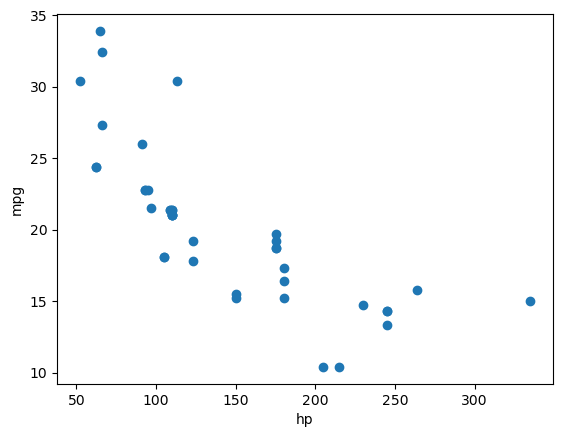

```python
import pandas as pd
import matplotlib.pyplot as plt

# load the dataset
df = pd.read_csv('mtcars.csv')

# scatter plot of mpg against hp
plt.scatter(df['hp'], df['mpg'])
plt.xlabel('hp')
plt.ylabel('mpg')
plt.show()
```

# Q7.7 Plot the histogram of the mpg using 30 bins and the y-axis show the count. Label the x and y axis.

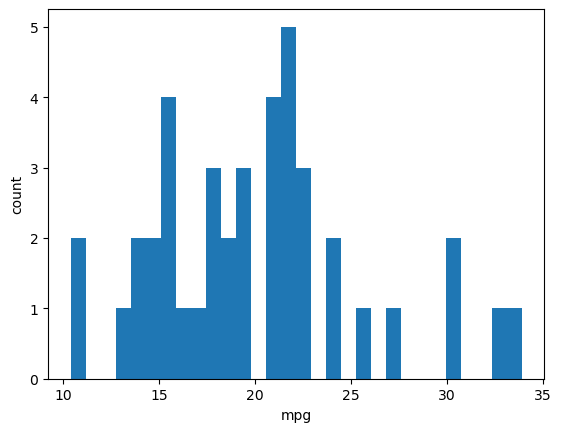

```python
import pandas as pd
import matplotlib.pyplot as plt

# load the dataset
df = pd.read_csv('mtcars.csv')

# plot histogram of mpg
plt.hist(df['mpg'], bins=30)
plt.xlabel('mpg')
plt.ylabel('count')
plt.show()
```

# Thank you Professor for you all Teachings and Support